# Day 1: Grammar of Graphics

Aaron R. Williams

## The Tidy Approach

### Opinionated software

> *Opinionated software* is a software product that believes a certain way of approaching a business process is inherently better and provides software crafted around that approach. ~ [Stuart Eccles](https://medium.com/@stueccles/the-rise-of-opinionated-software-ca1ba0140d5b)

### Tidy data

The defining opinion of the tidyverse is its wholehearted adoption of tidy data. Tidy data has three features:

1. Each variable forms a column.
2. Each observation forms a row.
3. Each type of observational unit forms a dataframe. (This is from the paper, not the book)

```r
knitr::include_graphics("tidy-data.png")
```

[output not shown]

Source: *[R for Data Science](https://r4ds.had.co.nz/tidy-data.html)*

Tidy data was formalized by Hadley Wickham in [“Tidy Data”](https://www.jstatsoft.org/article/view/v059i10) in the Journal of Statistical Software in 2014. It is equivalent to Codd’s 3rd normal form ([Codd, 1990](https://pdfs.semanticscholar.org/fed7/727e4864406ad69362f9500c93011dac7005.pdf)) for relational databases.

> Tidy datasets are all alike, but every messy dataset is messy in its own way. ~ [Hadley Wickham](https://r4ds.had.co.nz/tidy-data.html)

The tidy approach to data science is powerful because it breaks data work into two distinct parts. First, get the data into a tidy format. 2) Use tools optimized for tidy data. By standardizing the data structure for most community-created tools, the framework oriented diffuse development and reduced the friction of data work.

## Grammar of Graphics

```r
options(scipen = 999)

library(tidyverse)
```

The grammar of graphics, originally by Leland Wilkinson, is a theoretical framework that breaks all data visualizations into their component pieces. With the layered grammar of graphics, Wickham extends Wilkinson’s grammar of graphics and implements it in R. The cohesion is impressive and the theory flows to the code which informs the data visualization process in a way not reflected in any other data viz tool.

There are eight main ingredients to the grammar of graphics. We will work our way through the ingredients with many hands-on examples.

### Exercise 0

Step 1: Open your `.Rproj`.

Step 2: Open `02_workbook.Rmd`.

### Exercise 1

Step 1: **Type** (don’t copy & paste) the following code below `library(tidyverse)` in the new chunk where it says `# YOUR WORK GOES HERE`.

```
ggplot(data = storms) +
  geom_point(mapping = aes(x = pressure, y = wind))
```

Step 2: Add a comment above the ggplot2 code that describes the plot we created.

Step 3: Add comments below the data visualization code that describes the argument or function that corresponds to each of the first three components of the grammar of graphics.

1 Data are the values represented in the visualization.

`ggplot(data = )` or `data %>% ggplot()`

```r
storms %>%
  select(name, year, category, lat, long, wind, pressure) %>%
  sample_n(10) %>%
  knitr::kable()
```

| name | year | category | lat | long | wind | pressure |
| --- | --- | --- | --- | --- | --- | --- |
| Georges | 1998 | -1 | 9.7 | -25.1 | 30 | 1009 |
| Tanya | 1995 | -1 | 25.3 | -58.6 | 30 | 1002 |
| Luis | 1995 | 4 | 16.2 | -43.6 | 115 | 950 |
| Tanya | 1995 | 1 | 35.4 | -48.3 | 75 | 972 |
| AL041991 | 1991 | -1 | 14.7 | -29.6 | 25 | 1011 |
| Sandy | 2012 | 1 | 28.8 | -76.5 | 70 | 956 |
| Georges | 1998 | 1 | 21.3 | -77.2 | 70 | 990 |
| Claudette | 1979 | 0 | 28.3 | -93.5 | 40 | 1003 |
| Edouard | 1996 | 3 | 31.6 | -70.3 | 105 | 952 |
| Maria | 2011 | 0 | 16.9 | -61.1 | 45 | 1005 |

2 Aesthetic mappings are directions for how data are mapped in a plot in a way that we can perceive. Aesthetic mappings include linking variables to the x-position, y-position, color, fill, shape, transparency, and size.

`aes(x = , y = , color = )`

**X or Y**

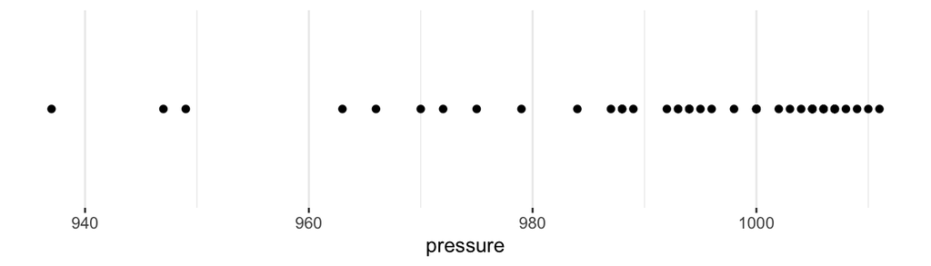

**Color or Fill**

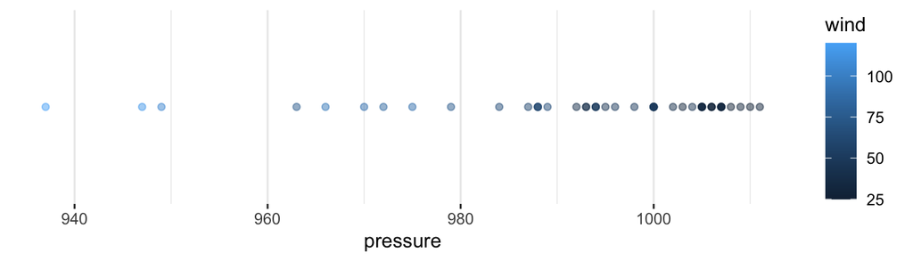

**Size**

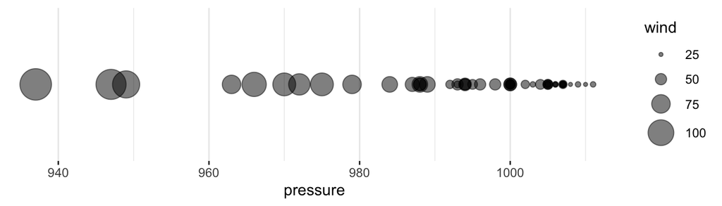

**Shape**

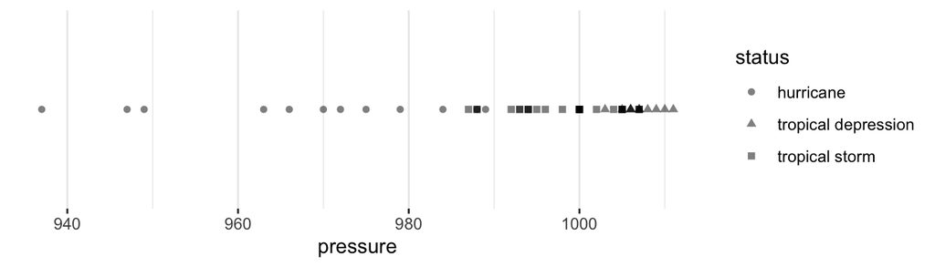

Others: transparency, animations, faceting

3 Geometric objects are representations of the data, including points, lines, and polygons.

*Plots are often called their geometric object(s).*

`geom_bar()` or `geom_col()`

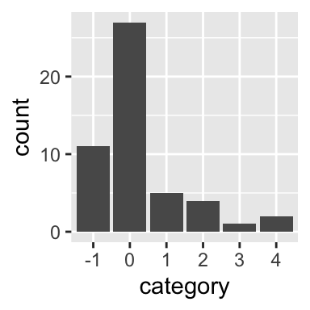

`geom_line()`

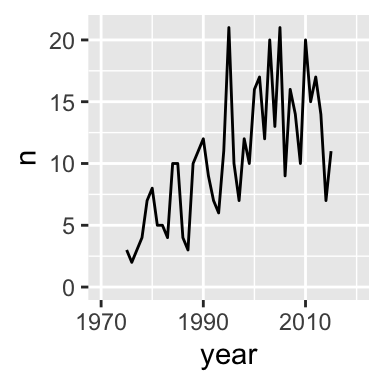

`geom_point()`

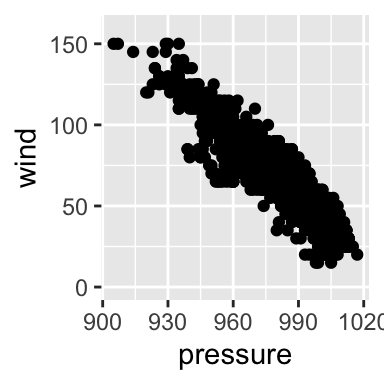

### Exercise 2

Step 1: Duplicate the code from exercise 1. Inside `aes()`, add `color = category`. Run the code.

Step 2: Replace `color = category` with `color = "green"`. Run the code. What changed? Is this unexpected?

Step 3: Remove `color = "green"` from `aes()` and add it inside inside of `geom_point()` but outside of `aes()`. Run the code.

Step 4: This is a little cluttered. Add `alpha = 0.2` inside `geom_point()` but outside of `aes()`.

Aesthetic mappings like x and y almost always vary with the data. Aesthetic mappings like color, fill, shape, transparency, and size can vary with the data. But those arguments can also be added as styles that don’t vary with the data. If you include those arguments in `aes()`, they will show up in the legend (which can be annoying! and is also a sign that something should be changed!).

### Exercise 3

Step 1: Create a new scatter plot using the `msleep` data set. Use `bodywt` on the x-axis and `sleep_total` on the y-axis.

Step 2: The y-axis doesn’t contain zero. Below `geom_point()`, add `scale_y_continuous(limits = c(0, NA))`. Hint: add `+` after `geom_point()`.

Step 3: The x-axis is clustered near zero. Add `scale_x_log10()` above `scale_y_continuous(limits = c(0, NA))`.

4 Scales turn data values, which are quantitative or categorical, into aesthetic values. This includes not only the x-axis and y-axis, but the ranges of sizes, shapes, and colors of aesthetics.

#### Before

`scale_x_continuous()`

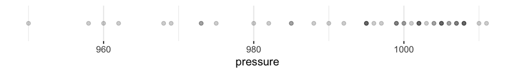

#### After

`scale_x_reverse()`

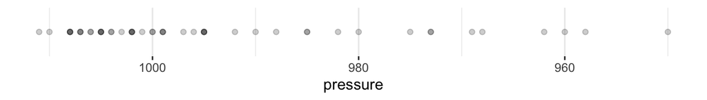

#### Before

`scale_size_continuous(breaks = c(25, 75, 125))`

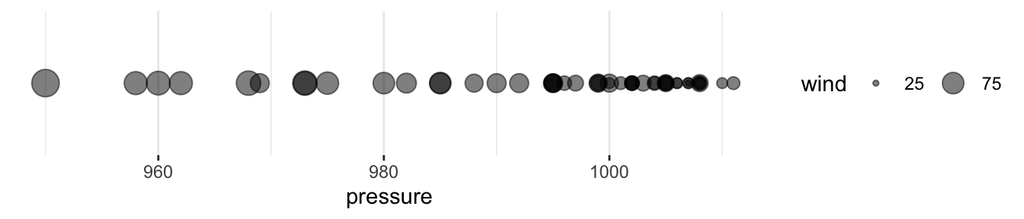

#### After

`scale_size_continuous(range = c(0.5, 20), breaks = c(25, 75, 125))`

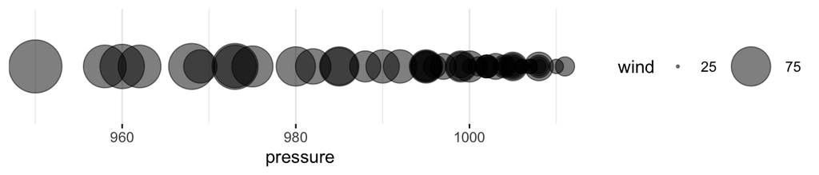

### Exercise 4

Step 1: Type the following code in your script.

```
data <- tibble(x = 1:10, y = 1:10)
ggplot(data = data) +
  geom_blank(mapping = aes(x = x, y = y))
```

Step 2: Add `coord_polar()` to your plot.

Step 3: Add `labs(title = "Polar coordinate system")` to your plot.

5 Coordinate systems map scaled geometric objects to the position of objects on the plane of a plot. The two most popular coordinate systems are the Cartesian coordinate system and the polar coordinate system.

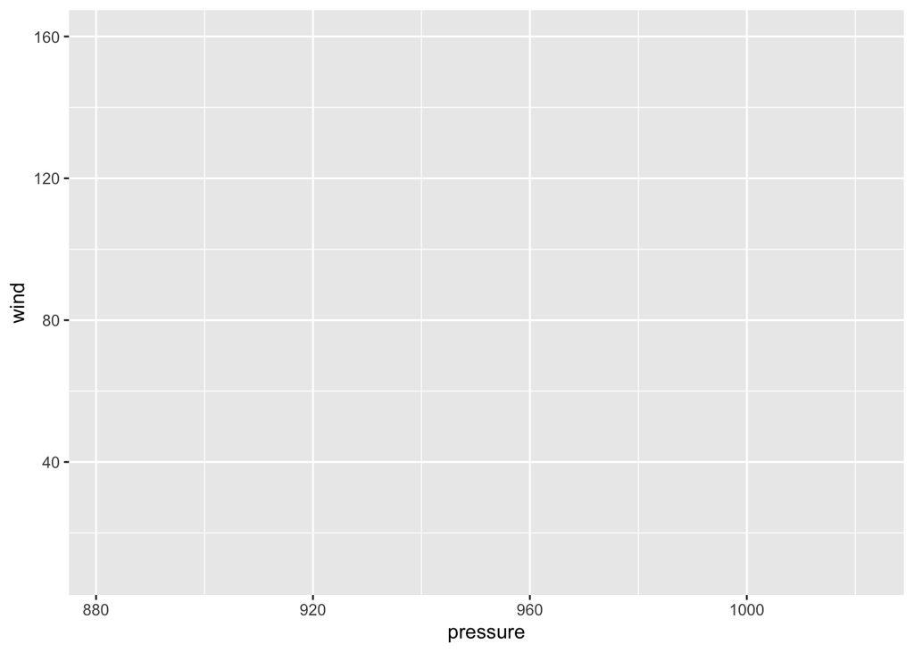

`coord_polar()`

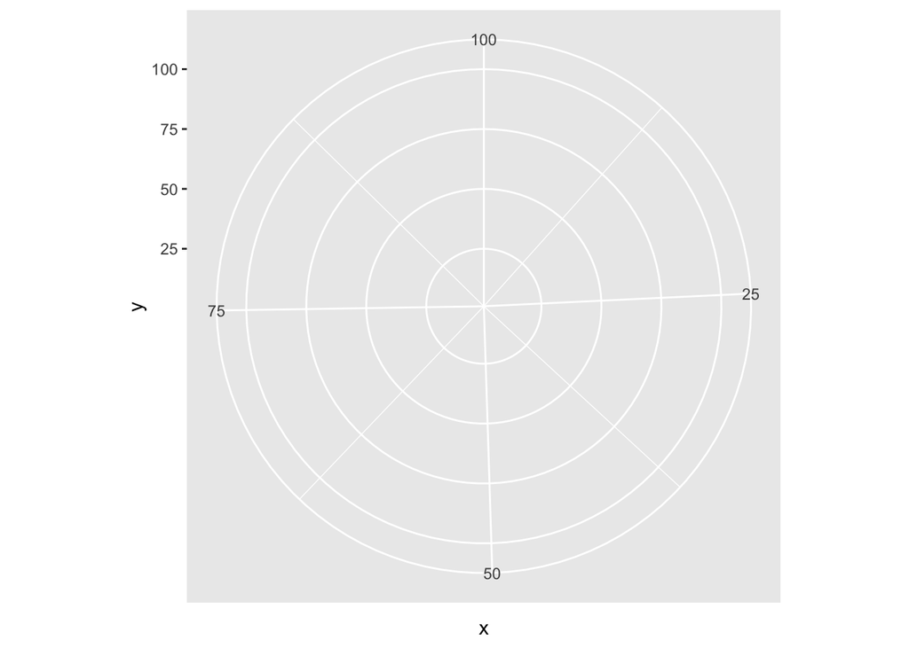

### Exercise 5

Step 1: Create a scatter plot of the `storms` data set with `pressure` on the x-axis and `wind` on the y-axis.

Step 2: Add `facet_wrap(~ category)`

6 Facets (optional) break data into meaningful subsets. `facet_wrap()`, `facet_grid()`, and `facet_geo()`.

#### facet_wrap()

`facet_wrap(~ category)`

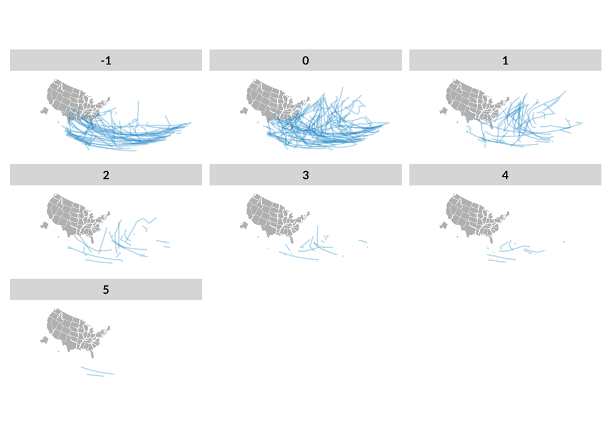

#### facet_grid()

`facet_grid(month ~ status)`

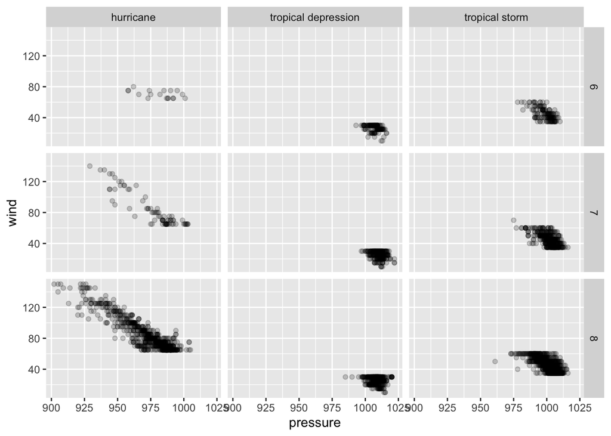

### Exercise 6

Step 1: Add the following code to your script. Submit it!

```
ggplot(storms) +
  geom_bar(mapping = aes(x = category))
```

7 Statistical transformations (optional) transform the data, typically through summary statistics and functions, before aesthetic mapping.

**Note:** `geom_bar()` performs statistical transformation. Use `geom_col()` to create a column chart with bars that encode individual observations in the data set.

### Exercise 7

Step 1: Duplicate Exercise 6.

Step 2: Add `theme_minimal()` to the plot.

### Exercise 8

Step 1: Duplicate Exercise 6.

Step 2: Run `install.packages("remotes")` and `remotes::install_github("UrbanInstitute/urbnthemes")` in the console.

Step 3: In the lines preceding the chart add and run the following code:

```
library(urbnthemes)
set_urbn_defaults(style = "print")
```

Step 4: Run the code to make the chart.

Step 5: Add `scale_y_continuous(expand = expand_scale(mult = c(0, 0.1)))` and rerun the code.

8 Theme controls the visual style of plot with font types, font sizes, background colors, margins, and positioning.

### Default theme

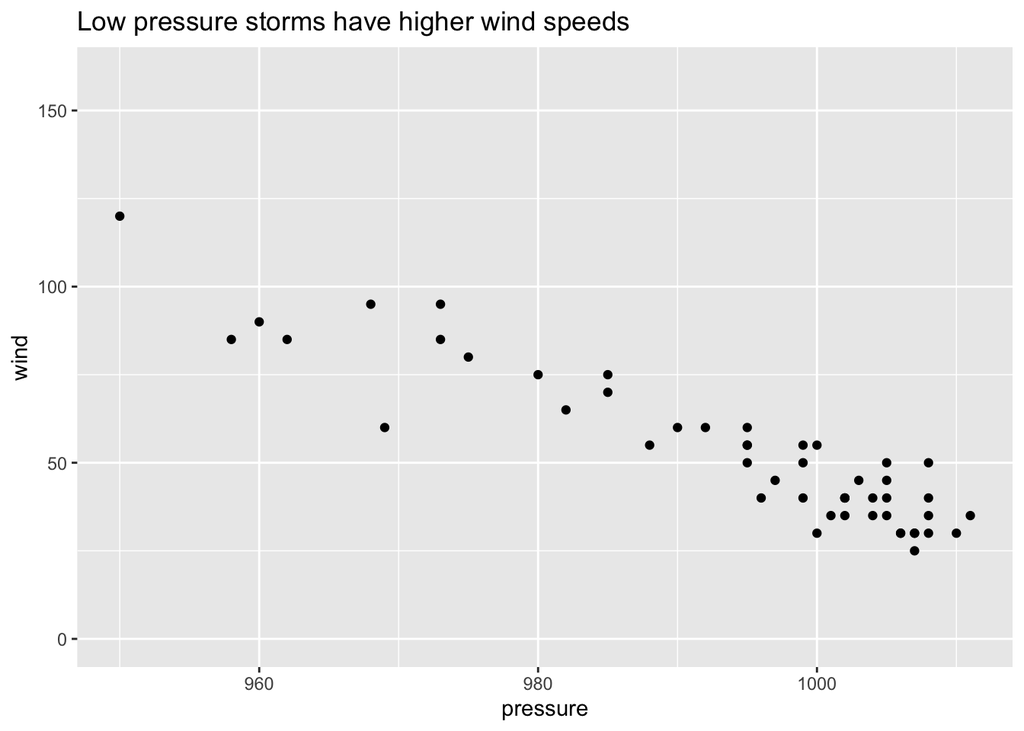

#### fivethirtyeight theme

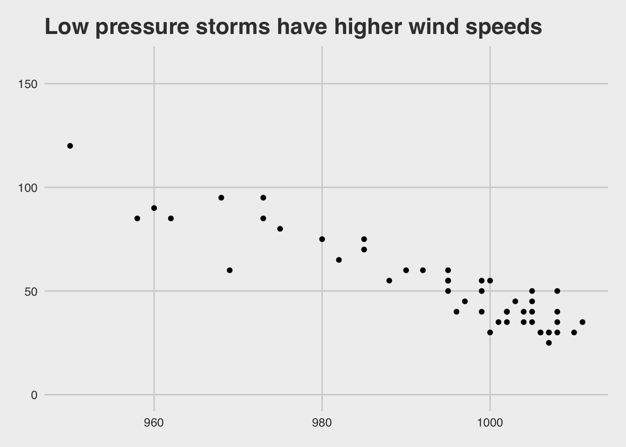

#### urbnthemes

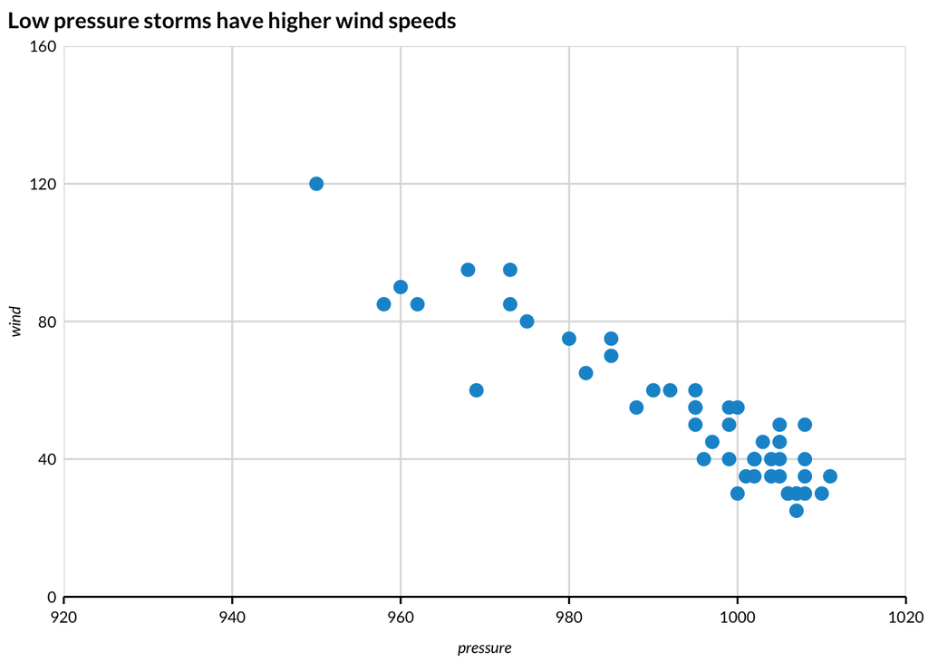

### Exercise 9 (layers!)

Step 1: Add the following exercise to you script. Run it!

```
storms %>%
  filter(category > 0) %>%
  distinct(name, year) %>%
  count(year) %>%
  ggplot() +
  geom_line(mapping = aes(x = year, y = n))
```

Step 2: Add `geom_point()` after `geom_line()`.

Layers allow for multiple geometric objects to be plotted in the same data visualization.

### Exercise 10

Step 1: Add the following exercise to you script. Run it!

```
ggplot(data = storms, mapping = aes(x = pressure, y = wind)) +
  geom_point() +
  geom_smooth()
```

Inheritances pass aesthetic mappings from `ggplot()` to later `geom_*()` functions.

### Exercise 11

Step 1: Pick your favorite plot from exercises 1 through 9 and duplicate it in a new code chunk.

Step 2: Add `ggsave(filename = "favorite-plot.png")` and then look at the saved file.

Step 3: Add `width = 6` and `height = 4` to `ggsave()`.

## Review

### Functions

- `ggplot()`
- `aes()`
- `geom_*()`
  - `geom_point()`
  - `geom_line()`
  - `geom_col()`
- `scale_*()`
  - `scale_y_continuous()`
- `coord_*()`
- `facet_*()`
- `labs()`
- `ggsave()`

### Theory

1. *Data*
2. *Aesthetic mappings*
3. *Geometric objects*
4. *Scales*
5. *Coordinate systems*
6. *Facets*
7. *Statistical transformations*
8. *Theme*

## Mapping

- [How to Create State and County Maps Easily in R](https://medium.com/@urban_institute/how-to-create-state-and-county-maps-easily-in-r-577d29300bb2)
- [library(urbnmapr)](https://github.com/UrbanInstitute/urbnmapr)
- [Urban Institute R Users Group website: mapping](https://urbaninstitute.github.io/r-at-urban/mapping.html)

## Resources

- [Urban Institute R Users Group website](https://urbaninstitute.github.io/r-at-urban/graphics-guide.html)
- [Why the Urban Institute visualizes data with ggplot2](https://medium.com/@urban_institute/why-the-urban-institute-visualizes-data-with-ggplot2-46d8cfc7ee67)
- [R for Data Science: data visualization](http://r4ds.had.co.nz/data-visualisation.html)
- [awunderground themes](https://awunderground.github.io/ggplot2-themes/)
- [R Graph Gallery](https://www.r-graph-gallery.com/)